# Web Scraping with R

Alex Sanchez (asanchez@ub.edu)  
GME Department. Universitat de Barcelona  
Statistics and Bioinformatics Unit. Vall d’Hebron Institut de Recerca

April 2019

# Readme

- License: Creative Commons Attribution-NonCommercial-ShareAlike 4.0 International License http://creativecommons.org/licenses/by-nc-sa/4.0/
- You are free to:
  - **Share** : copy and redistribute the material
  - **Adapt** : rebuild and transform the material
- Under the following conditions:
  - **Attribution** : You must give appropriate credit, provide a link to the license, and indicate if changes were made.
  - **NonCommercial** : You may not use this work for commercial purposes.
  - **Share Alike** : If you remix, transform, or build upon this work, you must distribute your contributions under the same license to this one.

# Disclaimer and acknowledgements

- These slides have been prepared based on multiple sources: websites, blogs, courses. While it is hard to cite them all I wish to acknowledge those sources that have been particularly useful.
  - [Tutorial-R-web-data](https://github.com/gastonstat/tutorial-R-web-data), by Gaston Sanchez
  - [Text Mining, Scraping and Sentiment Analysis with R](https://www.udemy.com/r-social-media-mining-scraping-with-twitter/) Udemy.
  - [Working with Web Data in R](https://www.datacamp.com/courses/working-with-web-data-in-r) Datacamp Course

# Objectives and Competences

- Become familiar with technologies for content dissemination on the web Information extraction from web-formatted data.
- Become familiar -*that is, know how to do it*- with the different tasks involved in web scraping.
- Learn how to set up and execute successful web scraping projects (making them as automatic, robust and error-resistant as possible).

# Contents

0. Introduction to web technologies & Overview
1. The basics: HTML and CSS
2. Text extraction with regular expressions
3. Using APIs to get data. Scrapping twiter.
4. XML basics. Parsing XML
5. Handling JSON data

# We need data, … and the web is full of it

- As *statisticians* (or is it as *data scientists*?) our work relies on having the appropriate data to work with.
- The web has plenty of data
  - In 2008, an estimated 154 million HTML tables (out of the 14.1 billion) contain ‘high quality relational data’!!!
  - Hard to quantify how much more exists outside of HTML Tables, but there is an estimate of at least 30 million lists with ‘high quality relational data’.
- Accessing the data in the web is the topic of this course

# What we need to know

- Technologies that allow the *distribution of content on the Web*.
- Techniques & Tools for *collecting* (as opposite to distributing) data from the web.
- In the way to acquiring these abilites we may learn many useful things that don’t necessarily have to do with web scraping such as:
  - HTML/CSS for creating web -and non web- pages (html is standard knitR output)
  - XML for sharing many types of data (also pdf, excel or epub)
  - Regular expressions for describing patterns in strings.
  - A variety of text mining and other interesting topics, such as “Sentiment Analysis” for analyzing data from Twitter, Linkedin etc.

# Technologies for disseminating, extracting, and storing web data

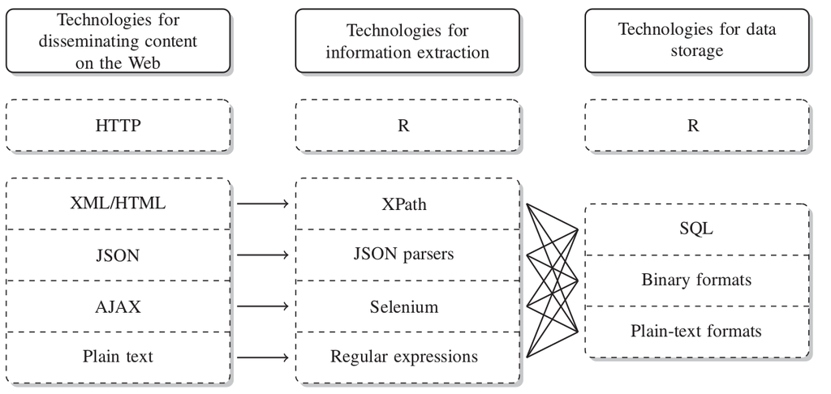

# Technologies (1): HTML

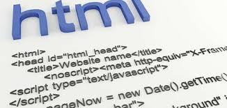

- **H**ypertext **M**arkup **L**anguage (HTML) is the language that all browsers understand.
- Not a dedicated data storage format but
- First option for containing information we look for.
- A minimum understanding of html required

# Technologies (2)

[figure not shown]

- CSS is the language for describing the presentation of Web pages, including colors, layout, and fonts.
- It allows one to adapt the presentation to different types of devices, such as large screens, small screens, or printers.
- CSS is independent of HTML and can be used with any XML-based markup language.

# Technologies (3): XML

[figure not shown]

- E**X**tensible **M**arkup **L**anguage or XML is one of the most popular formats for exchanging data over the Web.
- XML is “just” data wrapped in user-defined tags.
- The user-defined tags **make XML much more flexible** for storing data than HTML.

# Technologies (4): JSON

[figure not shown]

- JavaScript Object Notation or JSON
- JSON is a lightweight data-interchange format
- JSON is language independent but uses javascript syntax
- JSON is a syntax for storing and exchanging data.
- JSON is an easier-to-use alternative to XML

# Technologies (5) XML vs JSON

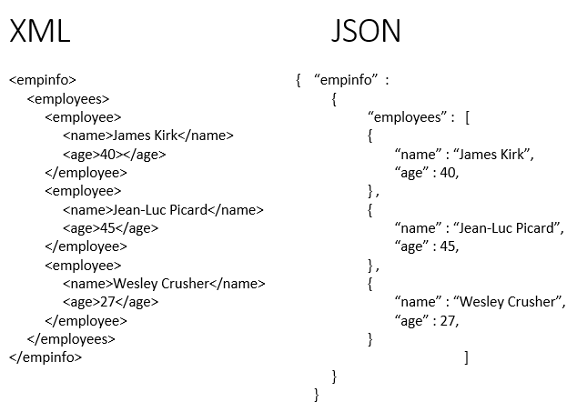

# Technologies (6): AJAX

[figure not shown]

- AJAX = Asynchronous JavaScript And XML.
- AJAX is a group of technologies that uses a combination of:
  - A user built-in XMLHttpRequest object (to request data from a web server)
  - JavaScript and HTML DOM (to display or use the data)
- AJAX allows web pages to be updated asynchronously by exchanging data with a web server behind the scenes.
- This means that it is possible to update parts of a web page, without reloading the whole page.

# Technologies (7): Regular Expressions

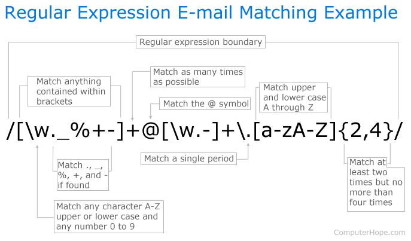

# So what is web scraping?

- Web scraping (web harvesting or web data extraction) is how we name computer software techniques for extracting information from websites.
  - See [Wikipedia](https://en.wikipedia.org/wiki/Web_scraping)
- Web scraping focuses on the *transformation of unstructured data* on the web, typically in web format such as HTML, XML or JSON, into *structured* data that can be stored and analyzed in a central local database or spreadsheet.
  - Instead of structured data, if using R, we can think of *[tidy](http://vita.had.co.nz/papers/tidy-data.pdf)* data.

# Understanding web communication: http

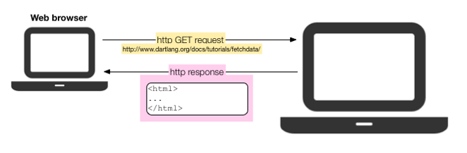

- User/Client asks for information: **http request**
- Server returns the information **http response**
- Data acquisition may be performed at two levels
  - Requesting information directly from the server
  - Parsing the response emited by the server

# Requesting & retrieving information directly

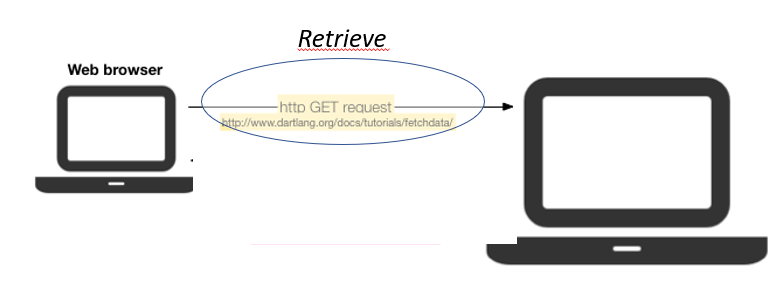

- Information retrieval can be made directly
  - in raw form through http GET requests
  - through an Application Programming Interface (API)
- There exist many APIs for retrieving data from “typical” places such as Twitter, Amazon, Linkedin, etc.
  - APIs require an authorization/user identification
- R packages
  - `httr`, `Rcurl`
  - `tweeteR`, `Rlinkedin`

# Parsing the server’s response

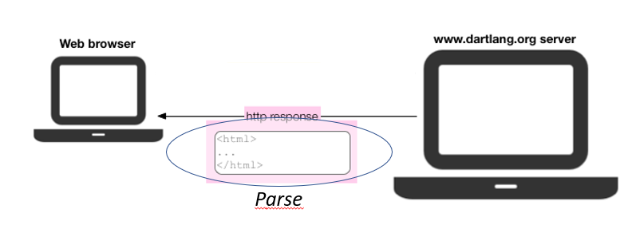

- Parser tools extract information from the response sent by the server to the browser.
- The response is usually an HTML / XML document.
- Parsers exploit the hierarchichal structure of HTML / XML to extract information and convert it into R objects
- R packages
  - `rvest`, `selectR`
  - `XML`, `xml2`

# The R scraping toolkit

- Comparison of some popular R packages for data collection.

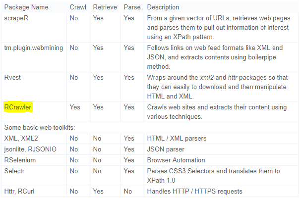

Source: **RCrawler: An R package for parallel web crawling and scraping**. Salim Khalil & MohamedFakir. https://doi.org/10.1016/j.softx.2017.04.004

# Web scraping and R

- Web scraping has been developed independently of R.  
  See for example:
  - [Scraping the Web for Arts and Humanities](https://www.essex.ac.uk/ldev/documents/going_digital/scraping_book.pdf)
  - [Introduction to Web Scraping using Scrapy and Postgres](http://newcoder.io/scrape/)
- There is a lot of information on scraping using python
- However if you feel comfortable working with R it is possible that you can absorbe easier and faster some of the the vast amount of resources for getting data from the web with R.

# The scrapping process

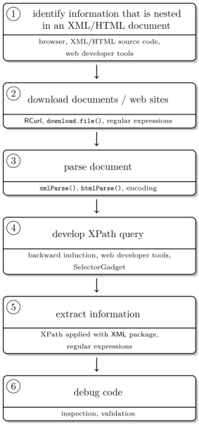

# Case Study 1: World heritage sites in danger

- The UNESCO is an organization of the United Nations which, among other things, fights for the preservation of the world’s natural and cultural heritage.
- As November 2013 there are 981 heritage sites, most of which of are man-made like the Pyramids of Giza, but also natural phenomena like the Great Barrier Reef are listed.
- Unfortunately, some of the awarded places are threatened by human intervention.
- These are the questions that we want to examine in this first case study.
  - *Which sites are threatened and where are they located?*
  - *Are there regions in the world where sites are more endangered than in others?*
  - *What are the reasons that put a site at risk?*

# Working through the case study with R

- This case study has been adapted from chapter 1 of the book [Automated Data Collection with R](http://www.r-datacollection.com/) (ADCR, from now on).
- Its goal is not to be exhaustive but providing a first example of a situation where we obtain and analyze data from the web.
- The goal is to tabulate and plot a list of endangered sites available in https://en.wikipedia.org/wiki/List_of_World_Heritage_in_Danger.
- We proceed as follows:
1. Go to the web and locate the desired information
2. Download the pages (here, HTML document)
3. Extract HTML table into an R object
4. Clean the data and build a data.frame
5. Plot and analyze

# Example 1a: Wikipedia page

[figure not shown]

# Example 1b: Locate desired table

[figure not shown]

# Example 1c: R code

```r
# load packages
library(stringr); library(XML); library(maps)
#--- parsing from locally stored HTML file
heritage_parsed <- htmlParse("worldheritagedanger.htm")
#--- Extract table from web page and select desired table
danger_table <- readHTMLTable(heritage_parsed, stringsAsFactors = FALSE, which = 2)
#--- select and rename columns
danger_table <- danger_table[,c(1,3,4,6,7)]
colnames(danger_table) <- c("name","locn","crit","yins","yend")
#--- Clean data
danger_table$crit <- ifelse(str_detect(danger_table$crit, "Natural")==T, "nat", "cult")
# cleanse years
danger_table$yins <- as.numeric(danger_table$yins)
danger_table$yend <- as.numeric(unlist(str_extract_all(danger_table$yend, "[[:digit:]]{4}$")))
#--- get countries
reg <- "[[:alpha:] ]+(?=[[:digit:]])"
danger_table$country <- str_extract(danger_table$locn , reg)
#--- get coordinates
reg_y <- "[/][ -]*[[:digit:]]*[.]*[[:digit:]]*[;]"
reg_x <- "[;][ -]*[[:digit:]]*[.]*[[:digit:]]*"
danger_table$y_coords <- as.numeric(str_sub(str_extract(danger_table$locn, reg_y), 3, -2))
danger_table$x_coords <-  as.numeric(str_sub(str_extract(danger_table$locn, reg_x), 3, -1))
#--- plot endangered heritage sites
par(oma=c(0,0,0,0)); par(mar=c(0,0,0,0))
pch <- ifelse(danger_table$crit == "nat", 19, 2)
map("world", col = "darkgrey", lwd = .5, mar = c(0.1,0.1,0.1,0.1))
points(danger_table$x_coords, danger_table$y_coords, pch = pch, col = "black", cex = .8)
box()
```

# Example 1d: We have an R data frame

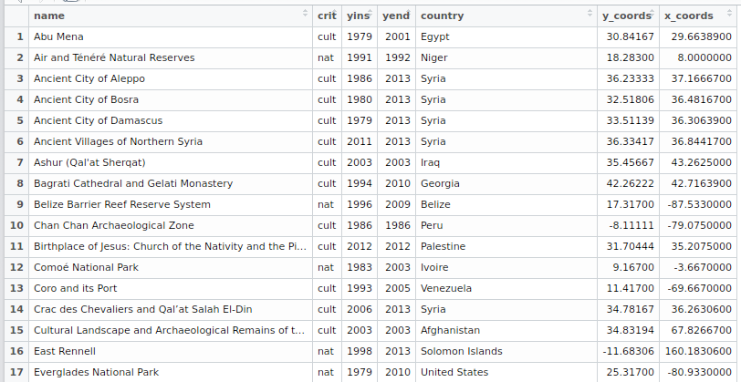

# Example 1e: And now the plot

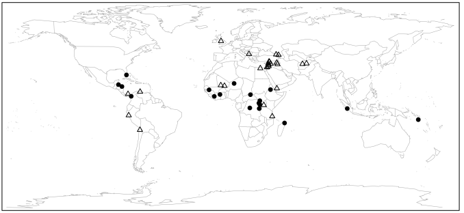

# References and resources

- [Automated Data Collection from the Web with R](http://www.r-datacollection.com/), by Munzer, Rubba, Meisner & Nyhulis. Wiley.
- [XML and Web Technologies for Data Science with R](http://www.rxmlwebtech.org/). Deborah Nolan & Duncan Temple Lang. UseR!
- [Introduction to Data Technologies](https://www.stat.auckland.ac.nz/~paul/ItDT/itdt-2013-03-26.pdf). Duncan Murdoch.
- [Getting Data from the Web with R](https://github.com/gastonstat/tutorial-R-web-data), by Gaston Sánchez.
- [Web scraping for the humanities and social sciences](http://quantifyingmemory.blogspot.co.uk/2014/02/web-scraping-basics.html), Rolf Fredheim and Aiora Zabala.
- [Web Scraping with R](http://cos.name/wp-content/uploads/2013/05/Web-Scraping-with-R-XiaoNan.pdf), by Xiao Nan.
- [R-bloggers posts on *Web Scraping*](http://www.r-bloggers.com/?s=web+scraping)
- And see also [CRAN Web Services and Technologies task view](https://cran.r-project.org/web/views/WebTechnologies.html)